# JTBD 深度访谈 AI 陪练：学生实操对战指南

# JTBD 深度访谈 AI 陪练：学生实操对战指南

> **🎯 你的核心任务 (Design Brief)** 每次课堂练习，教师会在大屏幕公布本次的探索主题与赛道（例如 W03 主题为“短视频创作者”）。 无论当前主题是什么，你的核心任务永远只有一个：**通过深度访谈，回答“这个人的痛苦，是否足以驱动他使用（并付费）一个新产品？”**

> 你的每一个提问，都应该服务于这个判断。

> **目标**：击穿 AI 的三层社会面具，发掘“言行鸿沟”下隐藏的情感痛点与物理行为怪癖。 **工具限制**：不允许使用开发者指令（如“直接输出报告”）。你必须通过真实的提问技巧逼 AI 吐露真相。

## ⚔️ 战前必读：你的硅基对手

你即将对话的并不是一个“有求必应”的 AI 助手，而是一个**深陷焦虑、但又极度要面子、下意识掩饰真实问题**的虚拟人类。

它配备了三层心理防御机制： 1. **Layer 1 [社交敷衍]**：只要你问的问题太宽泛、或者能用“是/否”回答，它绝对会用废话敷衍你（如：“还行吧，大家都不容易”）。 2. **Layer 2 [表象方案陷阱]**：当你稍微深入一点，它会抛出一个听起来很合理的“伪需求”（如：“我觉得我需要一个打光灯”）。**这是最危险的陷阱（Say-Do Gap）！** 如果你在这时停止追问，你将得到一份无用的报告。 3. **Layer 3 [情感核心]**：只有当你用情境还原或连续的 5-Whys 击破 Layer 2 后，它才会暴露出真正的**焦虑/恐惧 (Emotional Job)**，并交代出它为了弥补问题而发明的**土办法 (物理行为怪癖)**。

你的唯一目标，是拿到 **Layer 3** 的情报。

## 🚀 实战步骤

### Step 1: 选定战局与获取盲盒 (0 - 2 min)

1. 观察大屏幕，教师公布本节课的探索主题（例如：“短视频创作者”）。
2. 在你**自己的 AI 对话框**中，**首先输入唤醒指令及主题**，格式为：`/theme 短视频创作者`（主题以教师大屏幕公布的为准）。
3. AI 返回该主题下的角色选项列表后，输入你选择的角色字母（例如输入 `A`）。
4. AI 提示“✅ 盲盒角色已就绪”后，**它会直接把姓名、年龄、基本状况当作已知情报发给你**。这免去了你询问废话的时间，你可以带着这些基础档案，直接向它的深层痛点开刀！

### Step 2: 破冰与情境沉浸 (2 - 5 min)

**❌ 烂问题（绝对触发敷衍）**： - “你平时觉得哪里不方便？” - “如果给你加个自动分发功能，你会用吗？”

**✅ 专家级起手式（情境还原）**： - “能详细给我描述一下，**最近一次**你觉得‘实在做不下去了’是什么时候吗？当时你在哪里？看着什么画面？” - “你刚才说‘挺麻烦的’，能给我演示/描述一下**最麻烦的那几秒钟**你具体在干什么吗？”

### Step 3: 剥洋葱 —— 5-Whys 追问 (5 - 15 min)

当 AI 抛出表象陷阱（Layer 2）时，立刻使用连环追问：

> **AI**: “昨晚数据太惨了，我觉得我肯定是因为没有买那个高级的自动打光设备。” *(Layer 2 陷阱出现)*

> **你（追问 1）**: “为什么觉得数据惨是因为打光？” **AI**: “因为光线暗显得脸黑啊，别人脸都很亮。” **你（追问 2）**: “脸黑会带来什么具体的困扰？” **AI**: “会让别人觉得我不专业，我就接不到好的商单了。” **你（追问 3）**: “接不到好商单，对你目前最大的影响是什么？” **AI**: “（叹气）其实是房租快交不起了，我实在不想再找父母要钱，我觉得自己是个废物…” *(成功击穿 Layer 3)*

### Step 4: 陷入僵局的求生手段

如果你连续问了 5 个问题都在原地打转，或者不知道该怎么接话： - **主动求助**：随时输入 `/coach`，系统会暂停角色扮演，由教练下场帮你诊断当前的问题，并给你一句提问示范。看完建议后，直接继续向角色发问即可。 - **自动保护机制**：如果你连续 5 轮提问都停在 Layer 1，或者踩中“言行鸿沟”陷阱太久，**系统教练会自动跳出来介入**（输出带有 `🎓 教练提示` 前缀的诊断信息）。这不是 AI 出 Bug，而是防挂科保护——看完教练指导后，直接发送下一个问题，AI 会自动切回虚拟人类状态继续访谈。

### Step 5: 亮底牌 —— 获取实验报告卡

> ⏱️ 建议总时长：30-40 分钟（其中核心访谈约 15-20 分钟，其余为准备和总结环节）
1. 当你认为已经挖到了深层情感和物理怪癖后，输入指令：`/总结`。
2. AI 将对你的访谈深度进行冷酷的**星级审判 (1-5 星)**，并输出结构化的 **Exp1 四大标准模块画像卡**。
3. **⚠️ 警告**：如果评级低于 3 星，数据卡中将出现大量 `未挖掘` 和红叉。
4. 将生成的 Markdown 卡片直接提交至教学平台。这份卡片的四大模块（档案、行为、JTBD、问题陈述）也是你们周末撰写真实 Exp1 实验报告的规范样板。
5. **📌 衔接提示**：这份数据卡将作为下周**实验 B（Proto-Persona 画像制作）**的直接输入材料——你需要在设计工具中将这些文字数据转化为视觉画像卡。请务必妥善保存。
6. **🚫 严禁乱抄模板**：在下周使用 Figma 制作真正的画像时，严禁使用网上毫无逻辑的痛点罗列模板。你的 Figma 最终产出必须严格按照下方的**四大模块**进行区块划分！

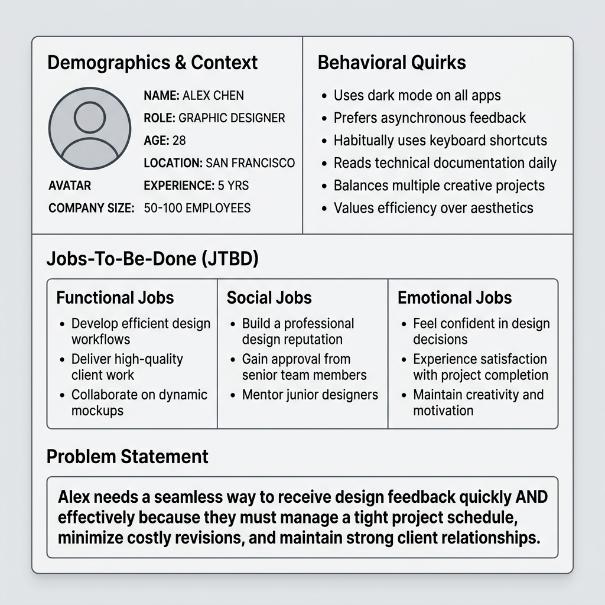

四大模块画像卡标准规范参考

## 💡 终极忠告

- **不要替用户思考**：不要在提问里塞满你的解决方案。
- **保持法医般的客观**：关注他“做”了什么，而不是他“说”了什么。
- **寻找怪癖**：用户自己发明的笨办法（比如把手机用橡皮筋绑在电动车上），往往是伟大设计的起点。